# DAND_Project2

## Introduction to Data Analysis Project

### The objective of this project is to investigate the Titanic dataset which contains the information for 891 people of the 2224 passangers on board of the Titanic that sank in North Atlantic Ocean in the early morning of 15 April, 1912, after colliding with an iceberg during her maiden voyage from Southampton to New York City [Wikipidia](https://en.wikipedia.org/wiki/RMS_Titanic). The objective of this investigation is to answer the following quastions based on the information provided in the dataset.

1. Who are the demography of the passangers onbaord (i.e, interms of sex, age, class etc.?
2. Which deck were the passagers on and how does that relate to their class?
3. Where did the passanges come from? (e.g, city, country etc)
4. What factors helped someone to survive

### First let us get started by loading the required modules for the data analysis

```python
import unicodecsv
import matplotlib.pylab as plt
import pandas as pd
from pandas import Series, DataFrame
import  numpy as np
import seaborn as sns
```

```python
#Having the neccessary modules for the analysis lets now load the Titanic dataset
# and using pands module

titanic_df = pd.read_csv('titanic-data.csv')
```

```python
# Lets have a general insight about the dataset by loading a portion of the dataset (head(), command )

titanic_df.head()
```

|  | PassengerId | Survived | Pclass | Name | Sex | Age | SibSp | Parch | Ticket | Fare | Cabin | Embarked |
| --- | --- | --- | --- | --- | --- | --- | --- | --- | --- | --- | --- | --- |
| 0 | 1 | 0 | 3 | Braund, Mr. Owen Harris | male | 22.0 | 1 | 0 | A/5 21171 | 7.2500 | NaN | S |
| 1 | 2 | 1 | 1 | Cumings, Mrs. John Bradley (Florence Briggs Th... | female | 38.0 | 1 | 0 | PC 17599 | 71.2833 | C85 | C |
| 2 | 3 | 1 | 3 | Heikkinen, Miss. Laina | female | 26.0 | 0 | 0 | STON/O2. 3101282 | 7.9250 | NaN | S |
| 3 | 4 | 1 | 1 | Futrelle, Mrs. Jacques Heath (Lily May Peel) | female | 35.0 | 1 | 0 | 113803 | 53.1000 | C123 | S |
| 4 | 5 | 0 | 3 | Allen, Mr. William Henry | male | 35.0 | 0 | 0 | 373450 | 8.0500 | NaN | S |

### The Titanic data set contains information about passanger ID, if passanger was survived or not (i.e. 1 is survived and o is dead) , name of passanger, sex, if passanger had childeren (i.e., 1 = had sibling and o = no sibling) , age, Parch (if they have parents at board, 1 = with parent and 0= with out parent), ticket, fare, cabin (contains deck information) and where they have boarded the Taitanic (Embark)

```python
## Now let us have a general qulitative infromation of the Titanic data set for each column using the 'info()' command
## on the dataframe
titanic_df.info()
```

```
<class 'pandas.core.frame.DataFrame'>
RangeIndex: 891 entries, 0 to 890
Data columns (total 12 columns):
PassengerId    891 non-null int64
Survived       891 non-null int64
Pclass         891 non-null int64
Name           891 non-null object
Sex            891 non-null object
Age            714 non-null float64
SibSp          891 non-null int64
Parch          891 non-null int64
Ticket         891 non-null object
Fare           891 non-null float64
Cabin          204 non-null object
Embarked       889 non-null object
dtypes: float64(2), int64(5), object(5)
memory usage: 83.6+ KB
```

### We can also see derscription of the data set , that is the descriptitve statistics such as count , mean , std , min, max and percentile (e.g. of Age ) . The avergae age of the passanger was about 29.67, minimum and maximum age of the passanger were 0.42 and 80 years respectively.

```python
titanic_df['Age'].describe()
```

```
count    714.000000
mean      29.699118
std       14.526497
min        0.420000
25%       20.125000
50%       28.000000
75%       38.000000
max       80.000000
Name: Age, dtype: float64
```

### From the above result we can have a general knowlege of how many records we have for each item or column, forexample we have only 204 records on 'Cabin' , we only know the age of 714 people from 891 passanger and etc.

### For the age varaibale there are about 177 passanger whose ages are not know, as age is a numerical value, it would be reseanably to replace each missing values with the mean age value.

```python
# Replacing missing age information with mean of age.
titanic_df['Age'].fillna(titanic_df['Age'].mean(), inplace=True)
titanic_df.info()
```

[output not shown]

### Having this in mind let us try to look for answere for the first question listed above, that is who were the passenger on board, their sex, age ,class and so on

```python
#Let us first see the class of the passangers, I use the 'groupby()' function

tit_group_byclass = titanic_df.groupby('Pclass').mean()

tit_group_byclass
```

| Pclass | PassengerId | Survived | Age | SibSp | Parch | Fare |
| --- | --- | --- | --- | --- | --- | --- |
| 1 | 461.597222 | 0.629630 | 37.048118 | 0.416667 | 0.356481 | 84.154687 |
| 2 | 445.956522 | 0.472826 | 29.866958 | 0.402174 | 0.380435 | 20.662183 |
| 3 | 439.154786 | 0.242363 | 26.403259 | 0.615071 | 0.393075 | 13.675550 |

```python
#Let us break down the data by both class and gender using the same 'groupby' function we used above
tit_grpby_sexclass = titanic_df.groupby(['Pclass','Sex']).mean()

tit_grpby_sexclass
```

| Pclass | Sex | PassengerId | Survived | Age | SibSp | Parch | Fare |
| --- | --- | --- | --- | --- | --- | --- | --- |
| 1 | female | 469.212766 | 0.968085 | 34.141405 | 0.553191 | 0.457447 | 106.125798 |
|  | male | 455.729508 | 0.368852 | 39.287717 | 0.311475 | 0.278689 | 67.226127 |
| 2 | female | 443.105263 | 0.921053 | 28.748661 | 0.486842 | 0.605263 | 21.970121 |
|  | male | 447.962963 | 0.157407 | 30.653908 | 0.342593 | 0.222222 | 19.741782 |
| 3 | female | 399.729167 | 0.500000 | 24.068493 | 0.895833 | 0.798611 | 16.118810 |
|  | male | 455.515850 | 0.135447 | 27.372153 | 0.498559 | 0.224784 | 12.661633 |

### From the groupings of titanic passanger by both class and sex (table above and the bar graph below), we can see that in all classes female passanger were younger than male passangers. And there are more number of males in all three classes.

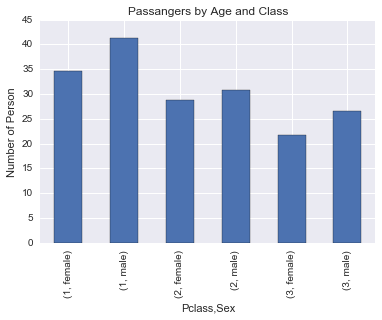

```python
%matplotlib inline
tit_grpby_sexclass['Age'].plot.bar()
plt.ylabel("Number of Person")
plt.title("Passangers by Age and Class");
```

## Lets plot the historgram to see age distribution of passanger. As we can see from the plot result most of the passagner's age was from 20 to 40 and ofcourse there were also considerable number of childeren of age less 10 years.

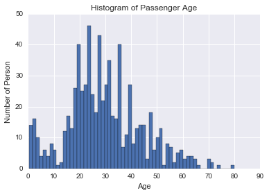

```python
titanic_df['Age'].hist(bins=60)
plt.xlabel("Age")
plt.ylabel("Number of Person")
plt.title("Histogram of Passenger Age");
```

### Now let us see the second quation, what deck where the passangers on and how does that relate to their class? For this we will analyze the mainly the 'Cabin' column. Let us create a python object called 'passanger_deck' from the titanic data. As there are only 204 information about cabin of passangers, it is difficult to use one of the method of filling missing data. So that, I employed the 'dropna()' function to exclude the missed information and the analysis were only made based on the available information of 204 passangers.

```python
# As the cabin column contains 'NaN' or missing data let us drop this using 'dropna()'
passanger_deck = (titanic_df).Cabin.str[:1].dropna()
passanger_deck.head()
```

```
1     C
3     C
6     E
10    G
11    C
Name: Cabin, dtype: object
```

### From the information above we see that the Cabin was represented by a letter and nubmers , where the letters (A,B,C, ...) represent the deck and the number following the letters represent Cabin number.

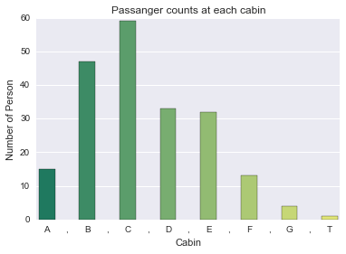

```python
deck_df = DataFrame(passanger_deck)
deck_df.columns = ['Cabin']
sns.countplot(x="Cabin", data=deck_df, palette="summer", order = "A,B,C,D,E,F,G,T")
plt.ylabel("Number of Person")
plt.title("Passanger counts at each cabin");
```

### There are only 204 passanger whose deck is known among the 891 passanger, fro the above plot of deck of passanger from the avialable information, many of the passangers were populated on deck C, B,D, E respectivily according to number of passangers. Coming to the third question where the passanger comes from, we need to analyse the 'Embark' column of the titanic dataset which contains the information C (from Cherbourg), Q(from Queenstown) and S(Southampton).

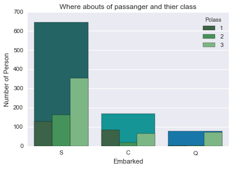

```python
#Plotting where the passangers comes from or embarked
sns.countplot(x="Embarked", data=titanic_df, palette="winter_d");
sns.countplot(x="Embarked", data=titanic_df, hue= 'Pclass', palette="Greens_d");
plt.ylabel("Number of Person")
plt.title("Where abouts of passanger and thier class");
```

### Above, I have ploted a bar graph of both where the passanger where embarked and the class of the of the passangers from each city, which depicts that many of the passengers (more than 600) were embarked from Southampton and many of the passanger (almost half of them) were third class.

### Coming to the last quastion about who survive and what factor probably contributed for thier survival , let us do different plolts of the varaibles and see if there is some relation among them. Fist let us as see how many people survived from sinking of Titanic.

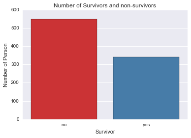

```python
# plot to see how many survived and for that lets change 0 and 1 to no or yes (yes for survivor and no , not survivor)
titanic_df['Survivor'] = titanic_df.Survived.map({0:'no',1:'yes'})
sns.countplot(x="Survivor", data=titanic_df, palette="Set1")
plt.ylabel("Number of Person")
plt.title("Number of Survivors and non-survivors");
```

### We can see from the above plot that most of the passanger (about 550) were perished during the crash only about less than 350 were survived. Now, let further our analysis by adding other factor to our analysis in this case sex and class of passangers. The bar graph below tells us that on many of the survivor were females and most of these passanger were in the first and secodn class. In the males case also the number of surviors in the first class were higher than the other classess. We may speculate that class of the passangers contributed on the survival rate of both female and male passanger., however in all class the number of female passanger surval was by far larger than that of male passanger, that might be due to the fact that priority for rescue could be given to female passangers.

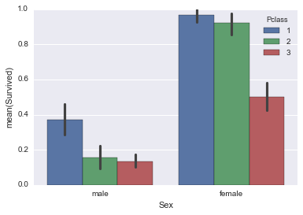

```python
sns.barplot(x="Sex", y="Survived", hue="Pclass", data=titanic_df)
```

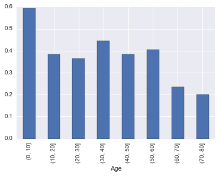

```python
group_by_age = pd.cut(titanic_df["Age"], np.arange(0, 90, 10))
age_grouping = titanic_df.groupby(group_by_age).mean()
age_grouping['Survived'].plot.bar()
```

### The two plot below are point plots , the first plot being the survival rate of passangers agianest sex per each class, in all cases the survival rate is scewed to the male passanger, that is the rate of survival for all class is very low as comared to female passangers. The second plot below depicts rate of survival for each gender agianst class, it clearly indicates that for all classes female passangers chance of survival is so high.

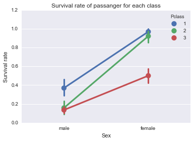

```python
sns.pointplot(x="Sex", y="Survived", hue="Pclass", data=titanic_df);
plt.ylabel("Survival rate")
plt.title("Survival rate of passanger for each class");
```

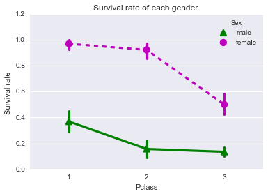

```python
sns.pointplot(x="Pclass", y="Survived", hue="Sex", data=titanic_df,
              palette={"male": "g", "female": "m"},
              markers=["^", "o"], linestyles=["-", "--"]);
plt.ylabel("Survival rate ")
plt.title("Survival rate of each gender ");
```

### Let us see how survival can be realted to age of passangers. I use the 'lmplot()' function investigate what kind of relation exist betwen age and survival rate. The plot below depicts the fact that surviral rate for female is positively correlate with age, that is as age of increases the survival rate increases , while for male passangers, the survival rate is negatively correlated with age , as age increases the survival for male passangers in minimal.

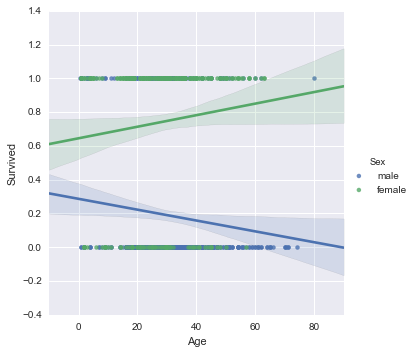

```python
# Age of passanger and survival rate
sns.lmplot('Age', 'Survived', data=titanic_df, hue='Sex')
```

### In conclusion attempts were made to analyse the titanic data which provides information for 891 passangers among the 2224 passanger who were on board during the trip. Which only containts information about 40% of the total passangers on board. Even though it could be possible to drive important insights from the dataset, it is difficult to draw conclusion based on the information as which factor contributed to survival fo passanger on board.So the analysis based on the avialable information from the dataset reveals that three factor:-sex, class and age are more correlated with the survival of the passanger. Due to the know fact that females and youngester are given priority for rescue it appears that sex and age are most important factors to detrmine survival. Class also has an important role for survival as first class passangers are more chance of get priorty for rescue. Given the fact that, most of the 'Cabin' information is missed it is really difficult to draw conclusion based on this information about survival rate. On the dataset, although it contains not all the information about all passangers of the 891 and all passangers on board of Titanic, it is a very organized and simplistic data set for starting to work with data analysis, and that prepares me to deal with a complex and more messy dataset of different format in my future data science career, provided that I would becoma a data scientist.

### Reference

1. http://napitupulu-jon.appspot.com/posts/titanic.html
2. http://www.kdnuggets.com/2016/07/titanic-machine-learning-guide-part-1.html
3. http://seaborn.pydata.org/tutorial/categorical.html
4. https://docs.scipy.org/doc/numpy/user/basics.creation.html